# Paritosh_Rai_Live_Session_Unit2_Assignment_Biv

## Question 5

### 5. Data Summary (30 points): Use your newly assigned data frame from question 4 for this question.

### a. Write an R command that gives you the column names of the data frame. Right after that, write one that counts the number of columns but not rows. Hint: The number should match one of your numbers in Question 1d for dimensions.

### b. Generate a count of each unique major_category in the data frame. I recommend using libraries to help. To be clear, this should look like a matrix or data frame containing the major_category and the frequency it occurs in the dataset. Assign it to major_count.

### c. To make things easier to read, put par(las=2) before your plot to make the text perpendicular to the axis. Make a barplot of major_count. Make sure to label the title with something informative (check the vignette if you need), label the x and y axis, and make it any color other than grey. Assign the major_category labels to their respective bar. Flip the barplot horizontally so that bars extend to the right, not upward. All of these options can be done in a single pass of barplot(). Note: Itâs okay if itâs wider than the preview pane.

### d. Write the fivethirtyeight data to a csv file. Make sure that it does not have row labels.

** List the column name and column count **

```r
#determine number of rows and column

dim(college_recent_grads)
```

```
## [1] 173  21
```

```r
# list the column names
colnames(college_recent_grads)
```

```
##  [1] "rank"                        "major_code"
##  [3] "major"                       "major_category"
##  [5] "total"                       "sample_size"
##  [7] "men"                         "women"
##  [9] "sharewomen"                  "employed"
## [11] "employed_fulltime"           "employed_parttime"
## [13] "employed_fulltime_yearround" "unemployed"
## [15] "unemployment_rate"           "p25th"
## [17] "median"                      "p75th"
## [19] "college_jobs"                "non_college_jobs"
## [21] "low_wage_jobs"
```

```r
#Number of columns only (no count of row)
ncol
```

[output not shown]

```
## function (x)
## dim(x)[2L]
## <bytecode: 0x0000000019e78408>
## <environment: namespace:base>
```

** Generate a count of each unique major_category in the data frame **

```r
# count of major category
df<-college_recent_grads
library(plyr)
maj_cat<-count(df$major_category)
```

** barplot of major_count **

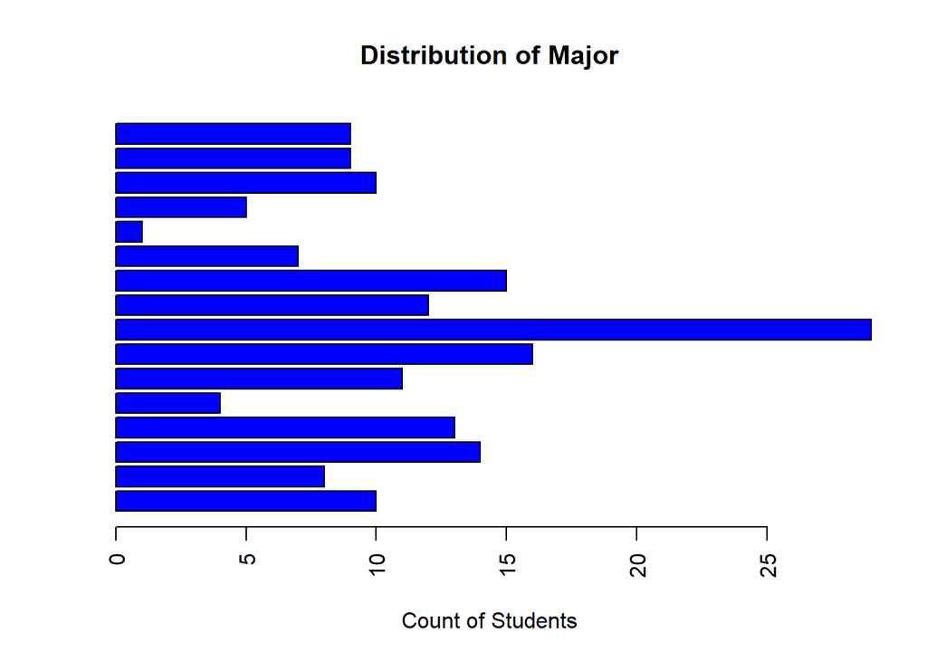

```r
# count of major category
maj_cat<-count(df$major_category)
# vertical lable
par(las=2)
#barplot
barplot(maj_cat$freq,main ="Distribution of Major", xlab="Count of Students",horiz = TRUE,axes = TRUE,col = "blue", cex.names = 0.5)
```

```r
#define working director to esnure file is written at right place
#setwd("C:/Paritosh/SMU/6306 Doing Data Science/Unit 3/Asst")
#write commond

write.table(maj_cat,"fivethirtyeight.csv")
```

## Question 6

##Codebook (30 points):

### a. Start a new repository on GitHub for your SMU MSDS homework. On your local device, make sure there is a directory for Homework at the minimum; you are welcome to add whatever you would like to this repo in addition to your requirements here.

### b. Create a README.md file which explains the purpose of the repository, the topics included, the sources for the material you post, and contact information in case of questions. Remember, the one in the root directory should be general. You are welcome to make short READMEs for each assignment individually in other folders.

### c. In one (or more) of the nested directories, post your RMarkdown script, HTML file, and data from âfivethirtyeight.â Make sure that in your README or elsewhere that you credit fivethirtyeight in some way.

### d. In your RMarkdown script, please provide the link to this GitHub so the grader can see it.

https://github.com/paritoshrai/MSDS_Homework/tree/master